# Statistical inference with the GSS data

## Part 4: Inference

As illustrated in the EDA above, the proportion of **Republican gun owners is .49** and the proportion of **Democrat gun owners is .37**. Next is to perform inference with a confidence interval and hypothesis test to determine if this difference in proportions is statistically significant.

**Conditions**

Due to the large sample size we can assume that each proportion will be able to be tested using the normal model. Also, the success-failure condition holds and the sample size is less than 10% of the population.

Secondly, we can assume that the study was done using a random sample and therefore independent as stated by the creators of the GSS survey.

Therefore we will continue by first conducting a hypothesis test and following with a confidence interval.  
**Hypothesis Test**

The hypothesis test results below show a very small p-value of .0001. This is below the significance level of .05 . Therefore, we can **reject the null hypothesis** and conclude that there is a difference in the proportion of gun ownership between Repbulicans and Democrats.

$H_0: p_{Republican} - p_{Democrat} = 0$;  
$H_A: p_{Republican} - p_{Democrat} \neq 0$;

```
## Response variable: categorical (2 levels, success: Yes)
## Explanatory variable: categorical (2 levels)
## n_Democrat = 16897, p_hat_Democrat = 0.3746
## n_Republican = 11635, p_hat_Republican = 0.4894
## H0: p_Democrat =  p_Republican
## HA: p_Democrat != p_Republican
## z = -19.2923
## p_value = < 0.0001
```

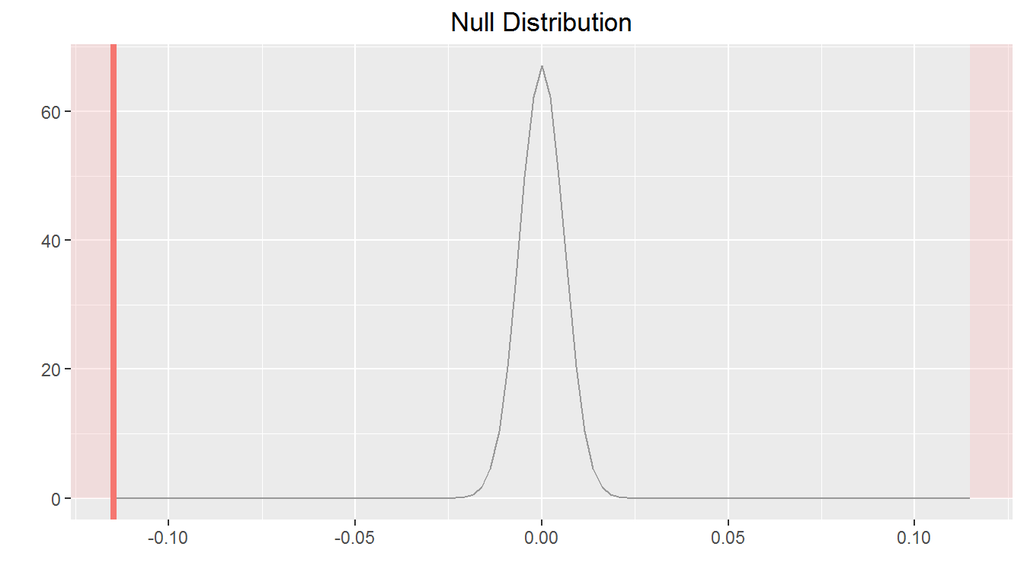

```r
inference(y = owngun, x = pol_party, data = pol_gun, statistic = "proportion", type = "ht", success="Yes", null = 0, alternative = "twosided", method = "theoretical", show_eda_plot = FALSE)
```

The null distribution chart above shows how far resulting value is from the null value.

**Confidence Interval**

The 95% confidence interval test below verifies the conclusion of the Hypothesis test since the interval does not include zero.

Therefore based on the results below, we can state that we are 95% confident that the difference in proportion of gun ownership between Democrats and Republicans lies somewhere between **-.10 and -.12**.

```r
inference(x = pol_party, y = owngun, data = pol_gun, statistic = "proportion", type = "ci", method = "theoretical", success = "Yes",show_eda_plot = FALSE)
```

```
## Response variable: categorical (2 levels, success: Yes)
## Explanatory variable: categorical (2 levels)
## n_Democrat = 16897, p_hat_Democrat = 0.3746
## n_Republican = 11635, p_hat_Republican = 0.4894
## 95% CI (Democrat - Republican): (-0.1264 , -0.1031)
```

**Conclusion**

The results of both of these tests indicate that there is evidence that there is a difference in the proportion of gun owners that are Republican vs Democrats and that Republicans generally own guns at a higher rate than Democrats.